# 05. Regulación y calibración de pulverizadoras

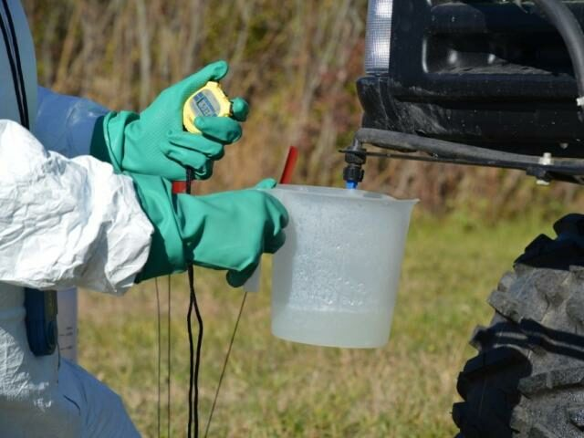

Fuente: www.no-tillfarmer.com. Estos conocimientos son clave para lograr **aplicaciones eficaces, seguras y responsables** de agroquímicos.

## Regulación

Consiste en **ajustar los componentes** de la pulverizadora para lograr la **dosis adecuada**, con buena cobertura y sin derivas*. Implica:

Algunos aspectos importantes con sus valores típicos son los siguientes:

- Selección de **boquillas** apropiadas (tipo, caudal, ángulo, material).
- Presión de trabajo (usualmente entre 2 y 4 bar para cobertura adecuada).
- Altura de barra (recomendada: 50 cm sobre el blanco para boquillas con 110°).
- Caudal del equipo y compatibilidad con el tractor.

> * Deriva es el **desplazamiento del producto fuera del área objetivo** por acción del viento o evaporación.

## Calibración

Luego de hacer los ajustes (regulaciones) necesarios hay que verificar que esto se cumpla en la realidad. Por esto la **calibración** es el proceso de **verificar y ajustar que lo regulado se cumpla en campo**.

Para calibrar una pulverizadora seguirás una metodología razonada, en la que no hay que memorizar ninguna fórmula compleja, explicada por los profesores Brouver y Silva de otra escuela agraria.

## Actividad 1

Observa este [fragmento de video](https://www.youtubetrimmer.com/view/?v=82mTNbPFTnw&start=46&end=103&loop=0) y completa correctamente el texto de abajo que explica la razón por la que hay que aprender esto. En cada línea va una sola palabra:

Si el operario de una ___ debe seguir la indicación de aplicar 1 litro por hectárea de un agroquímico debe verificar los ___ **reales** que entrega la máquina en condiciones normales para saber cuanto líquido debe ___ en el tanque para realzar el trabajo. Esto es calibrar.

## Actividad 2

Observa este [video](https://www.youtube.com/watch?v=h5FVrEP5ANc) en donde verás el proceso para la calibración de un equipo de pulverización autopropulsado Jacto 3030. Luego copia el proceso desarrollado abajo, paso a poso, completando fórmulas, datos y resultados según los datos del video:

[figure not shown]

Fuente: www.jacto.com.b. Pulverizadora Jacto 3030.

### Paso 1: Medir el ancho del equipo

Para esto se mide la distancia entre picos y se cuenta la cantidad de picos. En las fórmulas el asterisco significa multiplicación:

**Completar:** *Ancho del equipo = Distancia entre picos en metros * Cantidad de picos = ____ * 93 = ____ metros*

### Paso 2: Medir el tiempo que tarda en recorrer 50 metros

Se pone la pulverizadora en la velocidad normal de trabajo y se cronometra cuanto tarda en recorrer 50 metros.

**Completar:** En este equipo este tiempo fue de ___ segundos.

### Paso 3: Calcular el total de líquido que arrojan los picos (boquillas) al recorrer 50 metros

Para esto se hace funcionar la pulverizadora, estando parada pero largando agua, el mismo tiempo que tarda en recorrer 50 metros (paso anterior). Se recoge lo que largan tres picos en ese tiempo en tres jarras. Luego se saca un promedio del volumen que entrega cada pico y se multiplica por la cantiad de picos.

**Completar:**

- Las tres jarras juntas suman un volumen de ____ cm3 = ____ litros
- Para sacar el promedio se divide en 3 y resulta de ____ litros por pico
- Multiplicando por ____ picos da ____ litros. Estos son los litros que entrega una pulverizadora al recorrer 50 metros en condiciones normales de trabajo.

### Paso 4: Cálculo del agua que entrega el equipo por hectárea

Ahora se sabes cuantos litros entregó el equipo al recorrer 50 metros. Y también, teniendo en cuenta el ancho del equipo, puedes calcular la superficie que cubrió el equipo al recorrer esos 50 metros. Con este valor final se hace una regla de tres simple para calcular los litros por hectarea.

**Completar:**

- Superficie rociada al recorrer 50 metros = 50 m * ancho del equipo en metros = 50 m * ____ m = ____ m2
- Regla de 3 simple teniendo en cuenta que una hectárea son 10.000 m2:

```
   1.627,5  m2  _____  6,2 litros
   10.000   m2  _____  x

   x = ( ____ / ____ ) * 10.000 = 38,09 litros por hectárea

   La barra "/" significa dividido
```

## Actividad 3

Responder:

**1)** ¿Para qué se calcula el promedio en el paso 3? ¿que aporta a la metodología?

**2)** De acuerdo con el cálculo de la actividad anterior, suponiendo que la pulverizadora tiene un tanque de 2500 litros ¿Cuántas hectáreas puede rociar?

**3)** Si la pulverizadora anterior va más rápido y recorre los 50 metros en 8 segundos. Si además sumando el contenido de las 3 jarras que se llenaron en 8 segundos da 150 cm3 ¿Qué cantidad de litros por hectárea arroja la pulverizadora en estas condiciones?